# Reproducible Research: Peer Assessment 1

## Loading and preprocessing the data

First, make sure the data had been downloaded and put into the Working Directory  
Read the activity.csv using read.csv function

```r
#Read the activity.csv after this file was put into the working direction
Activity <- read.csv("activity.csv")

#Omit the data with no missing values
Activity_omit <- na.omit(Activity)
```

And we could take a glance of these two data, especially on NA’s.

```r
summary(Activity)
```

```
##      steps                date          interval
##  Min.   :  0.00   2012-10-01:  288   Min.   :   0.0
##  1st Qu.:  0.00   2012-10-02:  288   1st Qu.: 588.8
##  Median :  0.00   2012-10-03:  288   Median :1177.5
##  Mean   : 37.38   2012-10-04:  288   Mean   :1177.5
##  3rd Qu.: 12.00   2012-10-05:  288   3rd Qu.:1766.2
##  Max.   :806.00   2012-10-06:  288   Max.   :2355.0
##  NA's   :2304     (Other)   :15840
```

```r
summary(Activity_omit)
```

```
##      steps                date          interval
##  Min.   :  0.00   2012-10-02:  288   Min.   :   0.0
##  1st Qu.:  0.00   2012-10-03:  288   1st Qu.: 588.8
##  Median :  0.00   2012-10-04:  288   Median :1177.5
##  Mean   : 37.38   2012-10-05:  288   Mean   :1177.5
##  3rd Qu.: 12.00   2012-10-06:  288   3rd Qu.:1766.2
##  Max.   :806.00   2012-10-07:  288   Max.   :2355.0
##                   (Other)   :13536
```

## What is mean total number of steps taken per day?

We add the ‘steps’ colunm by each date to find out the total number of steps taken per day.

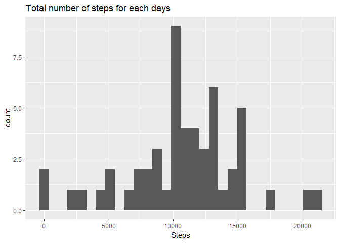

```r
#Calculate the total number of steps taken per day
act_sum <- aggregate(Activity$steps, by = list(Activity$date), sum)
names(act_sum) <- c("Date", "Steps_sum")

#Plot the histogram of the total number of steps taken per day
library(ggplot2)
g <- ggplot(act_sum, aes(Steps_sum))
g + geom_histogram(na.rm = TRUE) +
        labs(title = "Total number of steps for each days", x = "Steps")
```

```r
#Calculate and print the mean and median of the total number of steps taken per day
act_mean <- mean(act_sum$Steps_sum, na.rm = TRUE)
act_median <- median(act_sum$Steps_sum, na.rm = TRUE)
```

[output not shown]

## What is the average daily activity pattern?

Here we use the Activity_omit as the working data, whose missing value had been removed previously.  
We calculate the mean steps by each interval and plot a smooth line onto the dot pattern

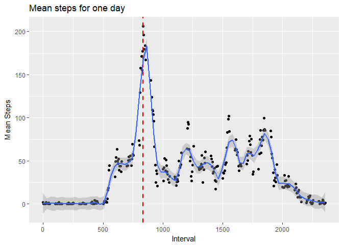

```r
#Calculate the mean steps taken per 5 minutes in each day
interval_mean <- aggregate(Activity_omit$steps, by = list(Activity_omit$interval), mean)
names(interval_mean) <- c("Interval", "Mean_Steps")
interval_mean$Interval <- as.numeric(as.character(interval_mean$Interval))
interval_mmax <- interval_mean$Interval[interval_mean$Mean_Steps == max(interval_mean$Mean_Steps)]

#Plot the mean steps taken per 5 minutes in each day and the max step line
g <- ggplot(interval_mean, aes(x = Interval, y = Mean_Steps))
g + geom_point() +
        geom_vline(xintercept = interval_mmax, col = "red", linetype = 2, lwd = 1) +
        geom_smooth(method = "loess", span = 0.1) +
        labs(title = "Mean steps for one day", x = "Interval", y = "Mean Steps")
```